# Building Upon Linear Models

Brandon LeBeau

February 27, 2017

The last week has focused on building simple linear models with a single predictor. This week will evaluate these models and build them up with more complexity. Particularly, this week will focus on ways to build models with predictors that have more than two categories, alternative ways to code categorical predictors, mixing categorical and quantitative variables, and interactions.

This section of notes will use the following packages.

```r
library(tidyverse)
library(modelr)
library(broom)
library(fivethirtyeight)
library(forcats)
```

## More than two categorical levels

Last week we explored a linear model framework for a two sample t-test (and the homework has you explore fitting a one-sample t-test in a linear model framework). I now want to generalize this idea to more than two categorical levels. It is traditional to think about these types of models as analysis of variance (ANOVA) models, however, the same model can be fitted in a linear model framework as well.

For this set of notes, we are going to make use of the gss_cat data found in the forcats package. Below are the first few rows of the data:

```r
gss_cat
```

| year | marital | age | race | rincome | partyid | relig | denom | tvhours |
| --- | --- | --- | --- | --- | --- | --- | --- | --- |
| 2000 | Never married | 26 | White | $8000 to 9999 | Ind,near rep | Protestant | Southern baptist | 12 |
| 2000 | Divorced | 48 | White | $8000 to 9999 | Not str republican | Protestant | Baptist-dk which | NA |
| 2000 | Widowed | 67 | White | Not applicable | Independent | Protestant | No denomination | 2 |
| 2000 | Never married | 39 | White | Not applicable | Ind,near rep | Orthodox-christian | Not applicable | 4 |
| 2000 | Divorced | 25 | White | Not applicable | Not str democrat | None | Not applicable | 1 |
| 2000 | Married | 25 | White | $20000 - 24999 | Strong democrat | Protestant | Southern baptist | NA |
| 2000 | Never married | 36 | White | $25000 or more | Not str republican | Christian | Not applicable | 3 |
| 2000 | Divorced | 44 | White | $7000 to 7999 | Ind,near dem | Protestant | Lutheran-mo synod | NA |
| 2000 | Married | 44 | White | $25000 or more | Not str democrat | Protestant | Other | 0 |
| 2000 | Married | 47 | White | $25000 or more | Strong republican | Protestant | Southern baptist | 3 |

[output cut: 990 more lines]

Suppose we were interested in exploring the relationship between the marital status of an individual and how much tv they watch. For example, perhaps married couples watch more tv compared to those that are single or never married. To get an idea of the categories in the marital variable, we could use the `count` function within dplyr.

```r
gss_cat %>%
  count(marital)
```

| marital | n |
| --- | --- |
| No answer | 17 |
| Never married | 5416 |
| Separated | 743 |
| Divorced | 3383 |
| Widowed | 1807 |
| Married | 10117 |

You’ll notice that there a few responses of “No Answer” and we may wish to treat these as missing values. This can be done with the `fct_recode` function as follows:

```r
gss_cat <- gss_cat %>%
  mutate(marital_miss = fct_recode(marital,
    NULL = 'No answer'
  ))
gss_cat %>%
  count(marital_miss)
```

| marital_miss | n |
| --- | --- |
| Never married | 5416 |
| Separated | 743 |
| Divorced | 3383 |
| Widowed | 1807 |
| Married | 10117 |
| NA | 17 |

We can now fit the model to this new data using the `lm` function.

```r
anova_mod <- lm(tvhours ~ marital_miss, data = gss_cat)
summary(anova_mod)
```

```
Call:
lm(formula = tvhours ~ marital_miss, data = gss_cat)

Residuals:
    Min      1Q  Median      3Q     Max
-3.9120 -1.6504 -0.6504  0.8948 21.3496

Coefficients:
                      Estimate Std. Error t value Pr(>|t|)
(Intercept)            3.10518    0.04679  66.366  < 2e-16 ***
marital_missSeparated  0.44444    0.13738   3.235  0.00122 **
marital_missDivorced  -0.01977    0.07680  -0.257  0.79687
marital_missWidowed    0.80682    0.09352   8.627  < 2e-16 ***
marital_missMarried   -0.45475    0.05879  -7.735 1.13e-14 ***
---
Signif. codes:  0 â€˜***â€™ 0.001 â€˜**â€™ 0.01 â€˜*â€™ 0.05 â€˜.â€™ 0.1 â€˜ â€™ 1

Residual standard error: 2.561 on 11323 degrees of freedom
  (10155 observations deleted due to missingness)
Multiple R-squared:  0.02141,   Adjusted R-squared:  0.02107
F-statistic: 61.94 on 4 and 11323 DF,  p-value: < 2.2e-16
```

To explore what the `lm` function is doing internally, the design matrix is a natural way to do this.

```r
model_matrix(gss_cat, tvhours ~ marital_miss)
```

| (Intercept) | marital_missSeparated | marital_missDivorced | marital_missWidowed | marital_missMarried |
| --- | --- | --- | --- | --- |
| 1 | 0 | 0 | 0 | 0 |
| 1 | 0 | 0 | 1 | 0 |
| 1 | 0 | 0 | 0 | 0 |
| 1 | 0 | 1 | 0 | 0 |
| 1 | 0 | 0 | 0 | 0 |
| 1 | 0 | 0 | 0 | 1 |
| 1 | 0 | 0 | 0 | 1 |
| 1 | 0 | 0 | 0 | 1 |
| 1 | 0 | 0 | 0 | 1 |
| 1 | 0 | 1 | 0 | 0 |

[output cut: 990 more lines]

Writing out this model with equations, the model looks like this:
$$tvhours_{i} = \beta_{0} + \beta_{1} Separated_{i} + \beta_{2} Divorced_{I} + \beta_{3} Widowed_{i} + \beta_{4} Married_{i} + \epsilon_{i}$$

If you are more familiar with ANOVA terminology, you can get an ANOVA table using the `anova` function on the model object.

```r
anova(anova_mod)
```

```
Analysis of Variance Table

Response: tvhours
                Df Sum Sq Mean Sq F value    Pr(>F)
marital_miss     4   1624  406.12  61.941 < 2.2e-16 ***
Residuals    11323  74239    6.56
---
Signif. codes:  0 â€˜***â€™ 0.001 â€˜**â€™ 0.01 â€˜*â€™ 0.05 â€˜.â€™ 0.1 â€˜ â€™ 1
```

Here you’ll notice that the F statistic is the same from the `lm` and `anova` functions showing that these are equivalent model calls.

#### Exercises

1. Using the martial_miss variable created above, what are the sample means of the five groups?
2. How do these sample means relate back to the parameters estimates shown above?
3. How could you visualize these models results? Attempt to create a visualization that captures the model results above.

### Adjusting the reference group

It is often of interest to adjust the reference group to make the intercept represent a specific group of interest. There are two approaches to take for this approach. The first I will show is using the forcats package to change the order of the levels of the variable.

Suppose for example, we wish to make the widowed category the reference group. This is the job of `fct_relevel` from the forcats package.

```r
gss_cat <- gss_cat %>%
  mutate(marital_m_widow = fct_relevel(
    marital_miss,
    'Widowed'
  ))
levels(gss_cat$marital_miss)
```

```
[1] "Never married" "Separated"     "Divorced"      "Widowed"       "Married"
```

```r
levels(gss_cat$marital_m_widow)
```

```
[1] "Widowed"       "Never married" "Separated"     "Divorced"      "Married"
```

You’ll notice that in the new variable, the widowed category was moved to the beginning and the remaining order was not changed. We can now fit a new model with this newly releveled factor variable.

```r
summary(lm(tvhours ~ marital_m_widow, data = gss_cat))
```

```
Call:
lm(formula = tvhours ~ marital_m_widow, data = gss_cat)

Residuals:
    Min      1Q  Median      3Q     Max
-3.9120 -1.6504 -0.6504  0.8948 21.3496

Coefficients:
                             Estimate Std. Error t value Pr(>|t|)
(Intercept)                   3.91200    0.08097  48.313  < 2e-16 ***
marital_m_widowNever married -0.80682    0.09352  -8.627  < 2e-16 ***
marital_m_widowSeparated     -0.36238    0.15245  -2.377   0.0175 *
marital_m_widowDivorced      -0.82659    0.10132  -8.159 3.75e-16 ***
marital_m_widowMarried       -1.26157    0.08845 -14.262  < 2e-16 ***
---
Signif. codes:  0 â€˜***â€™ 0.001 â€˜**â€™ 0.01 â€˜*â€™ 0.05 â€˜.â€™ 0.1 â€˜ â€™ 1

Residual standard error: 2.561 on 11323 degrees of freedom
  (10155 observations deleted due to missingness)
Multiple R-squared:  0.02141,   Adjusted R-squared:  0.02107
F-statistic: 61.94 on 4 and 11323 DF,  p-value: < 2.2e-16
```

The second approach to modifying which group represents the reference group would be to create the indicator (dummy) variables manually. The logic follows from the design matrix above, namely that each variable should have a value of 1 if the marital status equals a specific category or 0 otherwise. For example, this can be created as follows:

```r
gss_cat <- gss_cat %>%
  mutate(
    separated = ifelse(marital_miss == 'Separated', 1, 0),
    never_married = ifelse(marital_miss == 'Never married', 1, 0),
    divorced = ifelse(marital_miss == 'Divorced', 1, 0),
    married = ifelse(marital_miss == 'Married', 1, 0)
  )
summary(lm(tvhours ~ separated + never_married + divorced + married,
           data = gss_cat))
```

```
Call:
lm(formula = tvhours ~ separated + never_married + divorced +
    married, data = gss_cat)

Residuals:
    Min      1Q  Median      3Q     Max
-3.9120 -1.6504 -0.6504  0.8948 21.3496

Coefficients:
              Estimate Std. Error t value Pr(>|t|)
(Intercept)    3.91200    0.08097  48.313  < 2e-16 ***
separated     -0.36238    0.15245  -2.377   0.0175 *
never_married -0.80682    0.09352  -8.627  < 2e-16 ***
divorced      -0.82659    0.10132  -8.159 3.75e-16 ***
married       -1.26157    0.08845 -14.262  < 2e-16 ***
---
Signif. codes:  0 â€˜***â€™ 0.001 â€˜**â€™ 0.01 â€˜*â€™ 0.05 â€˜.â€™ 0.1 â€˜ â€™ 1

Residual standard error: 2.561 on 11323 degrees of freedom
  (10155 observations deleted due to missingness)
Multiple R-squared:  0.02141,   Adjusted R-squared:  0.02107
F-statistic: 61.94 on 4 and 11323 DF,  p-value: < 2.2e-16
```

Manually creating the variables has a few advantages, namely that there is a bit more flexibility on how the variables are created, but both approaches lead to the same model.

#### Exercises

1. Combine the ‘Never married’ and ‘Divorced’ categories into one category.
2. Fit a new model that combines these two categories. Does the model fit differ from the models shown above? Is this surprising?

### Post Hoc Tests

From the models fitted above, it may be of interest to conduct post hoc tests that compare all pairwise mean differences, particularly as the tests above are all compared to the reference group. This approach will be explored using the multcomp package and with defining linear contrasts.

```r
# install.packages("multcomp")
library(multcomp)
```

We first need to define linear contrasts based on the levels of the factor variable. For example, using the following model:

```r
gss_cat <- gss_cat %>%
  mutate(marital_m_widow = fct_recode(marital_m_widow,
           "Never_married" = "Never married"
  ))
anova_mod <- lm(tvhours ~ marital_m_widow, data = gss_cat)
levels(gss_cat$marital_m_widow)
```

```
[1] "Widowed"       "Never_married" "Separated"     "Divorced"      "Married"
```

We will use these level values to create linear contrasts that test all pairwise categories.

```r
my_contrasts <- c("Widowed - Never_married = 0",
                 "Widowed - Separated = 0",
                 "Widowed - Divorced = 0",
                 "Widowed - Married = 0",
                 "Never_married - Separated = 0",
                 "Never_married - Divorced = 0",
                 "Never_married - Married = 0",
                 "Separated - Divorced = 0",
                 "Separated - Married = 0",
                 "Divorced - Married = 0")
contr_results <- glht(anova_mod,
                      linfct = mcp(marital_m_widow = my_contrasts))
summary(contr_results)
```

```
     Simultaneous Tests for General Linear Hypotheses

Multiple Comparisons of Means: User-defined Contrasts


Fit: lm(formula = tvhours ~ marital_m_widow, data = gss_cat)

Linear Hypotheses:
                               Estimate Std. Error t value Pr(>|t|)
Widowed - Never_married == 0    0.80682    0.09352   8.627  < 0.001 ***
Widowed - Separated == 0        0.36238    0.15245   2.377  0.11076
Widowed - Divorced == 0         0.82659    0.10132   8.159  < 0.001 ***
Widowed - Married == 0          1.26157    0.08845  14.262  < 0.001 ***
Never_married - Separated == 0 -0.44444    0.13738  -3.235  0.00936 **
Never_married - Divorced == 0   0.01977    0.07680   0.257  0.99893
Never_married - Married == 0    0.45475    0.05879   7.735  < 0.001 ***
Separated - Divorced == 0       0.46421    0.14280   3.251  0.00918 **
Separated - Married == 0        0.89919    0.13398   6.711  < 0.001 ***
Divorced - Married == 0         0.43498    0.07054   6.166  < 0.001 ***
---
Signif. codes:  0 â€˜***â€™ 0.001 â€˜**â€™ 0.01 â€˜*â€™ 0.05 â€˜.â€™ 0.1 â€˜ â€™ 1
(Adjusted p values reported -- single-step method)
```

You can also specify different adjustment methods, such as the Benjamin-Hochberg method.

```r
summary(contr_results, test = adjusted("BH"))
```

```
     Simultaneous Tests for General Linear Hypotheses

Multiple Comparisons of Means: User-defined Contrasts


Fit: lm(formula = tvhours ~ marital_m_widow, data = gss_cat)

Linear Hypotheses:
                               Estimate Std. Error t value Pr(>|t|)
Widowed - Never_married == 0    0.80682    0.09352   8.627  < 2e-16 ***
Widowed - Separated == 0        0.36238    0.15245   2.377  0.01941 *
Widowed - Divorced == 0         0.82659    0.10132   8.159 1.48e-15 ***
Widowed - Married == 0          1.26157    0.08845  14.262  < 2e-16 ***
Never_married - Separated == 0 -0.44444    0.13738  -3.235  0.00152 **
Never_married - Divorced == 0   0.01977    0.07680   0.257  0.79687
Never_married - Married == 0    0.45475    0.05879   7.735 2.78e-14 ***
Separated - Divorced == 0       0.46421    0.14280   3.251  0.00152 **
Separated - Married == 0        0.89919    0.13398   6.711 4.04e-11 ***
Divorced - Married == 0         0.43498    0.07054   6.166 1.20e-09 ***
---
Signif. codes:  0 â€˜***â€™ 0.001 â€˜**â€™ 0.01 â€˜*â€™ 0.05 â€˜.â€™ 0.1 â€˜ â€™ 1
(Adjusted p values reported -- BH method)
```

Although defining the linear contrasts manually is more flexible, for simple models, the multiple comparisons can be generated a bit more simply.

```r
summary(glht(anova_mod, linfct = mcp(marital_m_widow = "Tukey")),
        test = adjusted("BH"))
```

```
     Simultaneous Tests for General Linear Hypotheses

Multiple Comparisons of Means: Tukey Contrasts


Fit: lm(formula = tvhours ~ marital_m_widow, data = gss_cat)

Linear Hypotheses:
                               Estimate Std. Error t value Pr(>|t|)
Never_married - Widowed == 0   -0.80682    0.09352  -8.627  < 2e-16 ***
Separated - Widowed == 0       -0.36238    0.15245  -2.377  0.01941 *
Divorced - Widowed == 0        -0.82659    0.10132  -8.159 1.48e-15 ***
Married - Widowed == 0         -1.26157    0.08845 -14.262  < 2e-16 ***
Separated - Never_married == 0  0.44444    0.13738   3.235  0.00152 **
Divorced - Never_married == 0  -0.01977    0.07680  -0.257  0.79687
Married - Never_married == 0   -0.45475    0.05879  -7.735 2.78e-14 ***
Divorced - Separated == 0      -0.46421    0.14280  -3.251  0.00152 **
Married - Separated == 0       -0.89919    0.13398  -6.711 4.04e-11 ***
Married - Divorced == 0        -0.43498    0.07054  -6.166 1.20e-09 ***
---
Signif. codes:  0 â€˜***â€™ 0.001 â€˜**â€™ 0.01 â€˜*â€™ 0.05 â€˜.â€™ 0.1 â€˜ â€™ 1
(Adjusted p values reported -- BH method)
```

You can also generate simultaneous confidence intervals:

```r
ci <- confint(summary(glht(anova_mod, linfct = mcp(marital_m_widow = "Tukey")),
                test = adjusted("BH")))
ci
```

```
     Simultaneous Confidence Intervals

Multiple Comparisons of Means: Tukey Contrasts


Fit: lm(formula = tvhours ~ marital_m_widow, data = gss_cat)

Quantile = 2.6893
95% family-wise confidence level


Linear Hypotheses:
                               Estimate lwr      upr
Never_married - Widowed == 0   -0.80682 -1.05833 -0.55532
Separated - Widowed == 0       -0.36238 -0.77236  0.04760
Divorced - Widowed == 0        -0.82659 -1.09907 -0.55412
Married - Widowed == 0         -1.26157 -1.49946 -1.02369
Separated - Never_married == 0  0.44444  0.07499  0.81390
Divorced - Never_married == 0  -0.01977 -0.22630  0.18676
Married - Never_married == 0   -0.45475 -0.61287 -0.29663
Divorced - Separated == 0      -0.46421 -0.84825 -0.08017
Married - Separated == 0       -0.89919 -1.25951 -0.53887
Married - Divorced == 0        -0.43498 -0.62469 -0.24527
```

These could then be visulized directly.

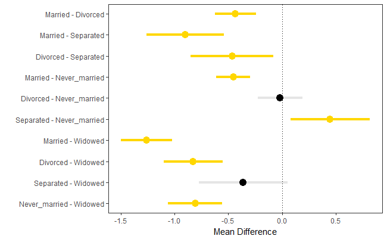

```r
SCI = data.frame(
  Contrast = 1:nrow(ci$confint),   #Contrast number
  MD = ci$confint[, 1],      #Mean difference
  LL = ci$confint[, 2],      #Lower limit
  UL = ci$confint[, 3],      #Upper limit
  Sig = c("Yes", "No", "Yes", "Yes", 'Yes', 'No',
          'Yes', 'Yes', 'Yes', 'Yes'),   #Statistically reliable?
  Alpha = c(1, .75, 1, 1, 1, .75, 1, 1, 1, 1),     #Transparency value
  Names = rownames(ci$confint)  # contrast label
)
# Plot of the simultaneous intervals
library(ggplot2)
ggplot(data = SCI, aes(x = Contrast, y = MD, color = Sig)) +
  geom_point(size = 4) +
  geom_segment(aes(x = Contrast, xend = Contrast, y = LL,
                   yend = UL, alpha = Alpha), lwd = 1.5) +
  geom_hline(yintercept = 0, lty = "dotted") +
  scale_color_manual(values = c("Black", "Gold")) +
  scale_x_continuous(
    name = "",
    breaks = 1:10,
    labels = SCI$Names
  ) +
  ylab("Mean Difference") +
  coord_flip() +
  theme_bw() +
  theme(
    legend.position = "none",
    panel.grid.minor = element_blank(),
    panel.grid.major = element_blank()
  )
```

#### Exercises

1. Fit a model that explores mean differences in tvhours by the party affiliation (partyid variable). Do the means differ?
2. Using the post-hoc tests, run post-hoc tests to test all pairwise differences.